# Advanced Empirical Finance: Topics and Data Science

Shrinkage for portfolio choice

Stefan Voigt

University of Copenhagen and Danish Finance Institute (DFI)

Spring 2027

## Where we are

- Lecture 3: plug-in portfolios lose out of sample. On the Dow Jones stocks, 1/N beat the plug-in minimum-variance portfolio, and the plug-in tangency portfolio was not investable
- The estimates $\hat\mu$ and $\hat\Sigma$ are noisy, but they are not useless

**Today:** instead of throwing the estimates away, pull them toward something simpler. That is **shrinkage**: a little bias for much less variance

# The covariance matrix in high dimensions

## Too many parameters

- $\Sigma$ has $N(N+1)/2$ parameters: 27 stocks give 378, estimated from 60 months of 27 returns
- With $N \geq T$, $\hat\Sigma$ is singular and has no inverse
- With $N < T$, it is invertible but ill-conditioned: its **smallest eigenvalues are too small** and its largest too large
- $\hat\Sigma^{-1}$ puts the most weight on the directions with the smallest eigenvalues: the portfolios that look almost riskless in the sample. Those are exactly the ones we estimate worst

## Estimated eigenvalues are too spread out

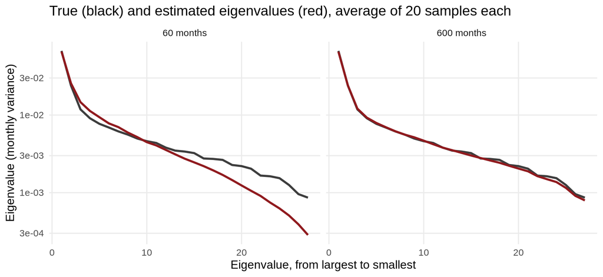

# Linear shrinkage

## Whiteboard: shrinking toward a target

Combine the sample covariance matrix $\hat\Sigma$ with a simple target $F$:
$$\hat\Sigma_\delta = \delta F + (1 - \delta)\hat\Sigma, \qquad \delta \in [0, 1]$$
Which $\delta$ minimizes the expected squared error $E\,\|\hat\Sigma_\delta - \Sigma\|^2 = E\sum_{i,j}(\hat\sigma_{\delta,ij} - \sigma_{ij})^2$?

For an unbiased $\hat\Sigma$ and a fixed target:

$$\delta^* = \frac{E\,\|\hat\Sigma - \Sigma\|^2}{E\,\|\hat\Sigma - F\|^2} = \frac{\sum_{i,j}\text{Var}(\hat\sigma_{ij})}{\sum_{i,j}E(\hat\sigma_{ij} - f_{ij})^2}$$

- More noise in $\hat\Sigma$: shrink more. A target far from the data: shrink less
- Ledoit and Wolf estimate both parts from the data, so $\hat\delta$ needs no tuning

## Targets and the Ledoit-Wolf estimator

- **A multiple of the identity**, $F = mI$ with $m$ the average variance (Ledoit & Wolf, 2004a): all variances equal, all correlations zero
- **Constant correlation**, the same correlation for every pair (Ledoit & Wolf, 2004b)
- **A single-factor model**, covariances from market betas (Ledoit & Wolf, 2003)
- R
- Python

```r
# Ledoit-Wolf (2004a): shrink toward the average variance times the identity
ledoit_wolf <- function(x) {
  t <- nrow(x)
  n <- ncol(x)
  x <- sweep(x, 2, colMeans(x))
  sample <- crossprod(x) / t
  m <- sum(diag(sample)) / n
  d2 <- sum((sample - m * diag(n))^2) / n
  b2 <- sum(map_dbl(seq_len(t), \(i) sum((tcrossprod(x[i, ]) - sample)^2))) / (n * t^2)
  delta <- min(b2, d2) / d2
  list(sigma = delta * m * diag(n) + (1 - delta) * sample, delta = delta)
}
```

```python
# Ledoit-Wolf (2004a): shrink toward the average variance times the identity
lw = LedoitWolf().fit(window)
sigma_lw = lw.covariance_
delta = lw.shrinkage_
```

## Shrinkage moves the minimum-variance portfolio

- With the target $mI$, the minimum-variance portfolio of the target is **1/N**: shrinkage moves the weights from the plug-in portfolio ($\delta = 0$) toward 1/N ($\delta = 1$)
- Ledoit-Wolf for the latest window: $\hat\delta$ = 0.15

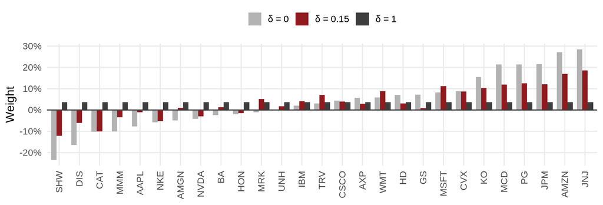

# Constraints as shrinkage

## Whiteboard: why no short sales help (Jagannathan & Ma, 2003)

Minimum variance with $\omega_i \geq 0$. With multipliers $\lambda_i \geq 0$, and $\lambda_i = 0$ whenever $\omega_i > 0$, the first-order conditions are
$$\Sigma\omega - \lambda = \lambda_0\iota$$

- $\omega_\text{no short}$ is the **unconstrained** minimum-variance portfolio of

$$\tilde\Sigma = \Sigma - (\lambda\iota' + \iota\lambda')$$

- For a stock the optimizer wants to short, the constraint lowers its variance by $2\lambda_i$ and its covariances by $\lambda_i + \lambda_j$: the constraint shrinks the large covariances that would have made the weight negative
- Wrong constraints, in theory, but in practice they shrink much like a covariance target does

# Shrinking expected returns

## Whiteboard: Bayes-Stein (Jorion, 1986)

Prior: all expected returns are equal, to the mean of the minimum-variance portfolio $\mu_\text{mvp}$. How far should $\hat\mu$ move toward $\mu_\text{mvp}\,\iota$?

$$\hat\mu_\text{BS} = (1 - w)\,\hat\mu + w\,\mu_\text{mvp}\,\iota, \qquad
w = \frac{N + 2}{(N + 2) + T\,(\hat\mu - \mu_\text{mvp}\iota)' S^{-1}(\hat\mu - \mu_\text{mvp}\iota)}$$

with $S = \frac{T - 1}{T - N - 2}\hat\Sigma$

- The more dispersed the means look relative to their noise, the less we shrink
- **Empirical Bayes:** the data choose the center and the strength of the prior

## Bayes-Stein in code

- R
- Python

```r
# Bayes-Stein (Jorion, 1986): shrink toward the mean of the mvp
bayes_stein <- function(x) {
  t <- nrow(x)
  n <- ncol(x)
  mu <- colMeans(x)
  s_inv <- solve(cov(x) * (t - 1) / (t - n - 2))
  mu_mvp <- sum(s_inv %*% mu) / sum(s_inv)
  d <- mu - mu_mvp
  w <- (n + 2) / ((n + 2) + t * as.numeric(t(d) %*% s_inv %*% d))
  list(mu = (1 - w) * mu + w * mu_mvp, w = w)
}
```

```python
# Bayes-Stein (Jorion, 1986): shrink toward the mean of the mvp
def bayes_stein(x):
    t, n = x.shape
    mu = x.mean(axis=0)
    s_inv = np.linalg.inv(np.cov(x, rowvar=False) * (t - 1) / (t - n - 2))
    mu_mvp = (s_inv @ mu).sum() / s_inv.sum()
    d = mu - mu_mvp
    w = (n + 2) / ((n + 2) + t * d @ s_inv @ d)
    return (1 - w) * mu + w * mu_mvp, w
```

For the latest 60-month window of the Dow Jones stocks: $w$ = 0.53. Bayes-Stein moves the expected returns about halfway to their common mean

## The Bayesian view

- Bayes-Stein is **empirical Bayes**: the prior’s center and strength come from the data
- A full Bayesian investor treats $\mu$ and $\Sigma$ as unknown and averages over them: the **predictive distribution** of returns
- With a diffuse prior, returns look riskier than $\hat\Sigma$ says, so the investor holds less in risky assets (Klein & Bawa, 1976)
- Priors can also come from economics, e.g. from an asset pricing model. An overview: Avramov & Zhou (2010)

# Back to the Dow Jones

## Five strategies

- **1/N**, the **plug-in minimum-variance** portfolio and the **minimum-variance portfolio without short sales** from lecture 3
- **Ledoit-Wolf minimum variance:** the minimum-variance portfolio of $\hat\Sigma_\text{LW}$
- **Bayes-Stein and Ledoit-Wolf tangency:** the tangency portfolio of $\hat\mu_\text{BS}$ and $\hat\Sigma_\text{LW}$
- R
- Python

```r
mvp <- function(sigma) {
  weights <- solve(sigma, rep(1, ncol(sigma)))
  weights / sum(weights)
}

tangency <- function(mu, sigma) {
  weights <- solve(sigma, mu)
  weights / sum(weights)
}
```

```python
def mvp(sigma):
    weights = np.linalg.solve(sigma, np.ones(sigma.shape[0]))
    return weights / weights.sum()

def tangency(mu, sigma):
    weights = np.linalg.solve(sigma, mu)
    return weights / weights.sum()
```

## The backtest

- R
- Python

```r
backtest <- map(seq(window_length + 1, nrow(excess_matrix)), \(t) {
  window <- excess_matrix[(t - window_length):(t - 1), ]
  sigma_hat <- cov(window)
  sigma_lw <- ledoit_wolf(window)$sigma
  returns_next <- excess_matrix[t, ]
  weights <- list(
    "1/N" = rep(1 / n_stocks, n_stocks),
    "Plug-in minimum variance" = mvp(sigma_hat),
    "Ledoit-Wolf minimum variance" = mvp(sigma_lw),
    "Minimum variance, no short sales" = min_variance_no_short(sigma_hat),
    "Bayes-Stein and Ledoit-Wolf tangency" = tangency(bayes_stein(window)$mu, sigma_lw)
  )
  tibble(
    date = excess_wide$date[t], strategy = names(weights), weights = weights,
    ret_excess = map_dbl(weights, \(w) sum(w * returns_next))
  )
}) |>
  bind_rows()
```

```python
records = []
for t in range(window_length, n_months):
    window = excess_matrix[t - window_length:t]
    sigma_hat = np.cov(window, rowvar=False)
    sigma_lw = LedoitWolf().fit(window).covariance_
    weights = {
        "1/N": iota / n_stocks,
        "Plug-in minimum variance": mvp(sigma_hat),
        "Ledoit-Wolf minimum variance": mvp(sigma_lw),
        "Minimum variance, no short sales": min_variance_no_short(sigma_hat),
        "Bayes-Stein and Ledoit-Wolf tangency": tangency(bayes_stein(window)[0], sigma_lw),
    }
    for strategy, w in weights.items():
        records.append({"date": excess_wide["date"][t], "strategy": strategy,
                        "ret_excess": w @ excess_matrix[t]})
backtest = pl.DataFrame(records)
```

The loop is the one from lecture 3; `excess_matrix`, `min_variance_no_short()` and the other inputs as there

## Out of sample, February 2005 to December 2025

| Strategy | Excess return | Volatility | Sharpe ratio | Turnover per month |
| --- | --- | --- | --- | --- |
| 1/N | 14.3% | 14.9% | 0.96 | 4% |
| Ledoit-Wolf minimum variance | 11.5% | 12.9% | 0.90 | 23% |
| Minimum variance, no short sales | 10.7% | 12.4% | 0.86 | 15% |
| Plug-in minimum variance | 12.4% | 15.8% | 0.78 | 60% |
| Bayes-Stein and Ledoit-Wolf tangency | 6.2% | 59.3% | 0.10 | 223% |

- Annualized, excess returns over the T-bill rate. Ledoit-Wolf beats the plug-in and the no-short-sale minimum-variance portfolios. Shrinking the means helps the tangency portfolio, but not enough

## How much shrinkage?

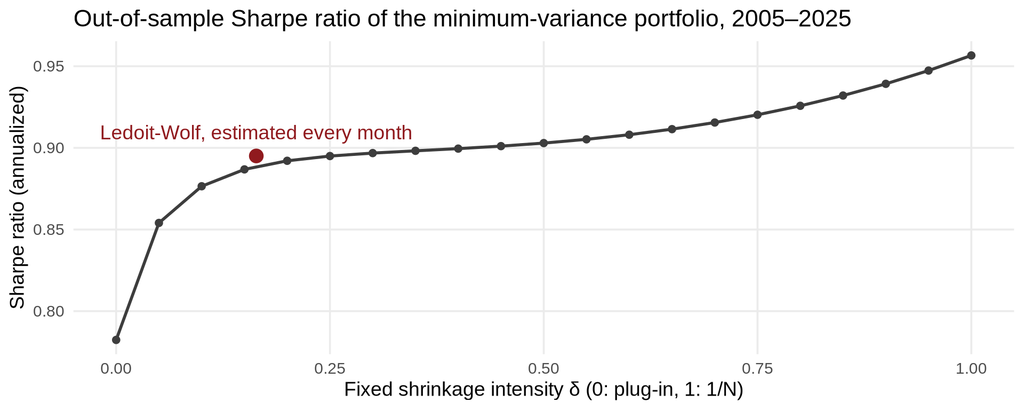

- Ledoit-Wolf chooses $\hat\delta$ between 0.10 and 0.23: optimal for estimating $\Sigma$, not for the portfolio. Here, more shrinkage pays all the way to 1/N, helped by the survivorship of today’s Dow Jones stocks
- Shrinkage aimed at the portfolio’s variance: Ledoit & Wolf (2017)

## Shrinkage everywhere

- Shrinkage trades a little bias for much less variance. The same idea returns as **ridge regression and the lasso** in the machine learning lectures
- Constraints, priors and targets are all ways to tell the optimizer what we believe before we see the data
- **Next lecture:** transaction costs act like shrinkage, too, and parametric portfolio policies

Assignment 1 on portfolio choice starts on 25 February